# Forschungspraktikum 1+2: Computational Social Science

Tutorial 05: Supervised Machine Learning

Dr. Christian Czymara

In this tutorial, we will work with survey data to practice data preparation, linear and logistic regression modeling, cross-validation, and model comparison.

## 0. Getting Started

Ensure the necessary R packages are installed and loaded. We will need:

- For data handling: `dplyr`, `tidymodels`
- For model building: `discrim`, `naivebayes`, `randomForest`,`kknn`, `kernlab`
- For evaluation: `yardstick`

```r
packages <- c(
  "dplyr",         # Data manipulation (filtering, grouping, summarizing)
  "tidymodels",    # Framework for modeling and machine learning workflows
  "discrim",       # Discriminant analysis models for classification
  "naivebayes",    # Naive Bayes
  "kernlab",       # Support Vector Machine
  "randomForest",  # Random Forest
  "kknn",          # K-Nearest Neighbors
  "yardstick"      # Model performance metrics (e.g., accuracy, precision)
  )

# install if necessary
install.packages(setdiff(packages, rownames(installed.packages())))

# load
lapply(packages, library, character.only = TRUE)
```

[output not shown]

[output cut: 43 more lines]

## 1. Data Preparation

### a) Data Import

1. Download the dataset from [this link](https://cssbook.net/d/media.csv)
2. Import it into R as an object named `media_data`
3. Remove any observations that have a missing value

```r
media_data <- na.omit(read.csv("https://cssbook.net/d/media.csv"))
```

### b) Generate a Binary Variable

Create a binary dependent variable for our analysis by recoding the variable `internet` as a factor where 0 is “non-user” and 1 “user”. How many people are internet users according to this definition?

```r
media_data$internet <- as.factor(ifelse(media_data$internet == 0, "non-user", "user"))

table(media_data$internet)
```

```
##
## non-user     user
##      803     1262
```

## 2. Splitting the Data

Next, we need to split the data set into training and test data. Use the `initial_split()` function to split the data into 75% training data and 25% testing data, stratified based on `internet` to ensure balanced classes in both training and testing sets.

```r
set.seed(1337)

media_data_split <- initial_split(media_data, prop = .75, strata = "internet")

train <- training(media_data_split)

test <- testing(media_data_split)
```

## 3. Logistic Regression

We will start with a logistic regression model to predict whether someone is an internet user - as generated in 1.b). - within the machine learning framework provided by `tidymodels`.

### a) Model Initialization

Set up a logistic regression model with `logistic_reg()` and assign it the “glm” engine (generalized linear model) using `set_engine("glm")`.

```r
log_model <- logistic_reg() %>%
  set_engine("glm")
```

### b) Recipe

We need to set the recipe, which in this case simply means specifying the model (preprocessing steps, like normalization and imputation, could also can be added here). Create a recipe where `internet` is the outcome, and `gender`, `age`, `education`, `radio`, `newspaper`, and `tv` are the predictors.

```r
internet_recipe <- recipe(internet ~ gender + age + education + radio + newspaper + tv, data = train)
```

### c) Workflow

Combine the recipe and the logistic model into a `workflow`.

```r
log_workflow <- workflow() %>%
  add_model(log_model) %>%
  add_recipe(internet_recipe)
```

### d) Train the Model

Fit the model on the training data to train the classifier.

```r
log_fit <- fit(log_workflow, data = train)
```

### e) Make Predictions on Test Data

Now that we trained the logistic model, use `predict()` to apply it to the *test* data. Add the predictions to the test data as a new column.

```r
log_predictions <- predict(log_fit, new_data = test)

test_2 <- bind_cols(test, log_predictions)

head(test)
```

```
##   gender age education radio newspaper tv internet
## 1      1  40         2     6         0  0 non-user
## 2      1  45         6     4         2  3     user
## 3      1  57         3     5         7  2 non-user
## 4      1  37         6     7         6  3     user
## 5      0  56         4     3         6  6 non-user
## 6      1  42         4     5         2  5     user
```

### f) Evaluate with Confusion Matrix

Use `conf_mat()` to create a confusion matrix. How did our classifier perform in the test data?

```r
confusion_matrix_log <- conf_mat(data = test_2, truth = internet, estimate = .pred_class)

confusion_matrix_log
```

```
##           Truth
## Prediction non-user user
##   non-user       67   53
##   user          134  263
```

### g) Precision and Recall

Using the values from the confusion matrix, calculate:

- *Precision:* How many predicted users are actually users ($\text{Precision} = \frac{TP}{TP + FP}$)
- *Recall:* How many actual users are correctly identified by the model ($\text{Recall} = \frac{TP}{TP + FN}$)
- *F1 Score:* The balance between precision and recall ($\text{F1} = 2 \times \frac{\text{Precision} \times \text{Recall}}{\text{Precision} + \text{Recall}}$)

```r
# True Positives (TP): Predicted as "user" and actually "user"
true_pos <- confusion_matrix_log$table["user", "user"]

# False Positives (FP): Predicted as "user" but actually "non-user"
false_pos <- confusion_matrix_log$table["user", "non-user"]

# False Negatives (FN): Predicted as "non-user" but actually "user"
false_neg <-confusion_matrix_log$table["non-user", "user"]

# Precision, Recall, and F1 calculations for "user" class
precision <- true_pos / (true_pos + false_pos)

precision
```

```
## [1] 0.6624685
```

```r
recall <- true_pos / (true_pos + false_neg)

recall
```

```
## [1] 0.8322785
```

```r
f1 <- 2 * (precision * recall) / (precision + recall)

f1
```

```
## [1] 0.7377279
```

```r
# or easier, using tidymodels:

levels(media_data$internet) # we are interested in the second level
```

```
## [1] "non-user" "user"
```

```r
# precision
precision(test_2, truth = internet, estimate = .pred_class, event_level = "second")
```

```
## # A tibble: 1 × 3
##   .metric   .estimator .estimate
##   <chr>     <chr>          <dbl>
## 1 precision binary         0.662
```

```r
# recall
recall(test_2, truth = internet, estimate = .pred_class, event_level = "second")
```

```
## # A tibble: 1 × 3
##   .metric .estimator .estimate
##   <chr>   <chr>          <dbl>
## 1 recall  binary         0.832
```

```r
# F1
f_meas(test_2, truth = internet, estimate = .pred_class, event_level = "second")
```

```
## # A tibble: 1 × 3
##   .metric .estimator .estimate
##   <chr>   <chr>          <dbl>
## 1 f_meas  binary         0.738
```

## 4. Cross Validation

Using one random sample split as test data can still lead to overfitting. A more rigorous validation is to perform it on various test samples and analyze the average fit. We want to do this for five samples (5-fold cross-validation) in the next exercise.

### a) Create Cross-Validation Folds

Use the `vfold_cv()` function to create 5 folds (subsets) for cross-validation from the training data, name the fold object `cv_folds`.

```r
set.seed(1337) # replicability

cv_folds <- vfold_cv(data = train, v = 5)
```

### b) Fit Model with Cross-Validation

Train the logistic regression model on each of the cross-validation folds applying the `fit_resamples()` function to the the workflow of 3.c).

To obtain metrics like F1 score, precision, and recall to assess the model’s average performance, first

- Create a new object: `my_metrics <- metric_set(yardstick::f_meas, yardstick::precision, yardstick::recall)`
- Use the two options `metrics = my_metrics` and `control = control_resamples(event_level = "second")` with `fit_resamples()`
- Then use the `collect_metrics()` function after fitting the model

```r
my_metrics <- metric_set(yardstick::f_meas, yardstick::precision, yardstick::recall)

log_cv <- fit_resamples(log_workflow,
                        resamples = cv_folds,
                        control = control_resamples(event_level = "second"),
                        metrics = my_metrics,
                        seed = 1337 # replicability
                        )

collect_metrics(log_cv)
```

```
## # A tibble: 3 × 6
##   .metric   .estimator  mean     n std_err .config
##   <chr>     <chr>      <dbl> <int>   <dbl> <chr>
## 1 f_meas    binary     0.745     5  0.0123 Preprocessor1_Model1
## 2 precision binary     0.674     5  0.0208 Preprocessor1_Model1
## 3 recall    binary     0.835     5  0.0126 Preprocessor1_Model1
```

## 5. Compare Classifiers

There are usually various algorithms available for classification tasks and choosing the best one is a matter of model performance in each case. In this final section, we’ll compare five classifiers to see which performs best at predicting internet use.

### a) Initialize Multiple Models

Set up engines and models for these five classifiers (look at the pages we loaded in 0., then apply the code chunk below):

1. Logistic Regression
2. Naive Bays
3. Support Vector Machine
4. Random Forest
5. K-Nearest Neighbors

```r
log_model <- logistic_reg() %>%
  set_engine("glm") %>%
  set_mode("classification")

nb_model <- naive_Bayes() %>%
  set_engine("naivebayes") %>%
  set_mode("classification")

svm_model <- svm_linear() %>%
  set_engine("kernlab") %>%
  set_mode("classification")

rf_model <- rand_forest() %>%
  set_engine("randomForest") %>%
  set_mode("classification")

knn_model <- nearest_neighbor(neighbors = 4) %>%
  set_mode("classification")
```

### b) Recipe for All Classifiers

The recipe will be the same for all classifiers: We will predict `internet` by all other variables in the dataset (`gender`, `age`, `education`, `radio`, `newspaper`, and `tv`). Set up the according recipe and call it `all_model_recipe`.

```r
all_model_recipe <- recipe(internet ~ ., data = train)
```

### c) Workflow Set

Combine the recipe with each model in a `workflow_set()`, creating the workflows for each model. Name this workflow set `model_workflow_set`.

```r
model_workflow_set <-workflow_set(
  preproc = list(all_model_recipe),
  models = list(log_model, nb_model, svm_model, rf_model, knn_model)
  )
```

### d) Train Models with Cross-Validation

Train each model across the cross-validation folds to get performance metrics for each. Use the following code:

```r
model_cv_results <- workflow_map(model_workflow_set,
                                 "fit_resamples",
                                 resamples = cv_folds,
                                 metrics = my_metrics,
                                 control = control_resamples(event_level = "second"),
                                 seed = 1337 # replicability
                                 )
```

### e) Evaluate Results

Collect and review the metrics of each model. Identify the model with the best cross-validation results and determine which performs best based on its F1 score.

```r
collect_metrics(model_cv_results)
```

```
## # A tibble: 15 × 9
##    wflow_id         .config preproc model .metric .estimator  mean     n std_err
##    <chr>            <chr>   <chr>   <chr> <chr>   <chr>      <dbl> <int>   <dbl>
##  1 recipe_logistic… Prepro… recipe  logi… f_meas  binary     0.745     5 0.0123
##  2 recipe_logistic… Prepro… recipe  logi… precis… binary     0.674     5 0.0208
##  3 recipe_logistic… Prepro… recipe  logi… recall  binary     0.835     5 0.0126
##  4 recipe_naive_Ba… Prepro… recipe  naiv… f_meas  binary     0.761     5 0.0114
##  5 recipe_naive_Ba… Prepro… recipe  naiv… precis… binary     0.670     5 0.0191
##  6 recipe_naive_Ba… Prepro… recipe  naiv… recall  binary     0.882     5 0.0104
##  7 recipe_svm_line… Prepro… recipe  svm_… f_meas  binary     0.754     5 0.00945
##  8 recipe_svm_line… Prepro… recipe  svm_… precis… binary     0.664     5 0.0198
##  9 recipe_svm_line… Prepro… recipe  svm_… recall  binary     0.875     5 0.0119
## 10 recipe_rand_for… Prepro… recipe  rand… f_meas  binary     0.730     5 0.0105
## 11 recipe_rand_for… Prepro… recipe  rand… precis… binary     0.692     5 0.0171
## 12 recipe_rand_for… Prepro… recipe  rand… recall  binary     0.774     5 0.0182
## 13 recipe_nearest_… Prepro… recipe  near… f_meas  binary     0.668     5 0.0144
## 14 recipe_nearest_… Prepro… recipe  near… precis… binary     0.677     5 0.0213
## 15 recipe_nearest_… Prepro… recipe  near… recall  binary     0.660     5 0.0139
```

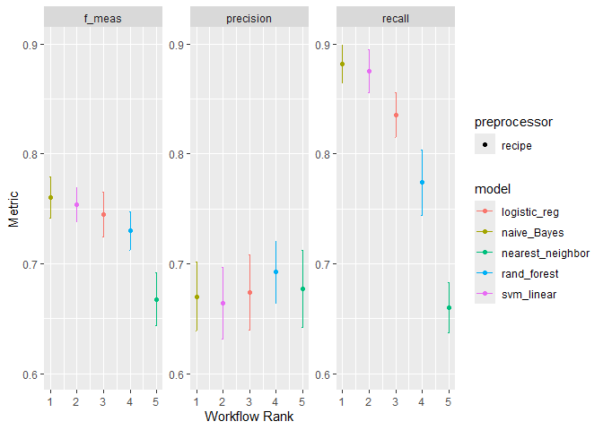

```r
autoplot(model_cv_results) + scale_y_continuous(limits = c(.6, .9))
```

### f) Final Model Fit and Prediction

Use the `extract_workflow` function to select the best-performing model identified in step 5.e). Fit this model to the full training data.

Use this final model to predict internet use on the test data and evaluate its performance.

```r
best_workflow <- extract_workflow(model_cv_results, id = "recipe_naive_Bayes")

best_fit_model <- fit(best_workflow, train)

predictions <- predict(best_fit_model, new_data = test)

precision(bind_cols(test, predictions), truth = internet, estimate = .pred_class, event_level = "second")
```

```
## # A tibble: 1 × 3
##   .metric   .estimator .estimate
##   <chr>     <chr>          <dbl>
## 1 precision binary         0.668
```

```r
recall(bind_cols(test, predictions), truth = internet, estimate = .pred_class, event_level = "second")
```

```
## # A tibble: 1 × 3
##   .metric .estimator .estimate
##   <chr>   <chr>          <dbl>
## 1 recall  binary         0.867
```

```r
f_meas(bind_cols(test, predictions), truth = internet, estimate = .pred_class, event_level = "second")
```

```
## # A tibble: 1 × 3
##   .metric .estimator .estimate
##   <chr>   <chr>          <dbl>
## 1 f_meas  binary         0.755
```